# Fysik, statistik och lite artificiell intelligens - en bild av den moderna ingenjören

## Christian Forssén

### Teoretisk subatomär fysik, Institutionen för fysik, Chalmers

#### 2018-01-18, SNF Cocktail party

- Denna presentation är baserad på en [ipython](https://ipython.org/) notebook. Själva presentationen är en [Reveal.js](https://revealjs.com/#/) HTML slideshow skapad genom nbconvert direkt från ovan nämnda notebook.
- Allt material och källkod är samlat i säkert men publikt [git](https://git-scm.com/) förvar (ett s.k. "git repository") på [github](https://github.com/cforssen/SNFcocktail), tillgängligt för alla och envar att ladda ner och testa själv.

  ```
  [~]$ git clone https://github.com/cforssen/SNFcocktail.git
  [~]$ cd SNFcocktail
  ```

- Se också [Teoretisk subatomär fysiks](http://fy.chalmers.se/subatom/tsp/index.php) hemsida (se ["for students"](http://fy.chalmers.se/subatom/tsp/index.php?page=teaching)).

## Innehåll

- Först lite fysik
- ... och lite statistik i två olika skepnader
- ... plus lite beräkningsfysik
- Sedan en ny horisont genom att kombinera fysik och statistik med maskininlärning
- ... och slutligen framträder en bild av den moderna ingenjören!

## Att kvantifiera sin osäkerhet är inte lätt...

> Ett militärt angrepp mot Sverige är osannolikt.

Stefan Löfvén, 2018.

> Ett väpnat angrepp på Sverige kan inte uteslutas.

Försvarsberedningen, 2017.

### Inom naturvetenskap är kunskap om osäkerheter av stor betydelse.

#### Referenser

- Intressant och lärorik bloggpost ["Frequentism and Bayesianism: A Practical Introduction"](http://jakevdp.github.io/blog/2014/03/11/frequentism-and-bayesianism-a-practical-intro/) på bloggen [Pythonic Perambulations](http://jakevdp.github.io).
- Litteratur: [Data Analysis: A Bayesian Tutorial](https://global.oup.com/academic/product/data-analysis-9780198568322?cc=se&lang=en&) och [Bayesian Logical Data Analysis for the Physical Sciences](https://www.cambridge.org/core/books/bayesian-logical-data-analysis-for-the-physical-sciences/09E9A95DAE275F5B005676C71B542598)
- [GPy](http://sheffieldml.github.io/GPy/) en pythonmodul för Gaussprocesser (GP), från maskininlärningsgruppen på Sheffield University.
- [TensorFlow](https://www.tensorflow.org/) ett öppet programbibliotek för maskinintelligens genom neurala nätverk. Det utgör basen för [Keras](https://keras.io/): ett python API för Deep Learning.
- ... för min del började detta med ett 26-dimensionellt optimeringsproblem inom utvecklandet av effektiva fältteorier, en gedigen statistisk analys (samt några mycket hängivna kandidatarbetare och en väldigt duktig doktorand): [Phys. Rev. X 6 (2016) 011019](https://journals.aps.org/prx/abstract/10.1103/PhysRevX.6.011019).

## Python

Att installera Python, samt de bibliotek som möjliggör vetenskapliga beräkningar, är inte särskilt svårt.

Jag rekommenderar Anaconda, med pakethanteraren conda, som fungerar för Windows, Linux, och Mac OS X.

- [Anaconda](https://www.continuum.io/downloads) inkluderar både Python och conda, samt ett antal förinstallerade paket. Denna distribution tar dock en hel del plats. Ett alternativ är [Miniconda](http://conda.pydata.org/miniconda.html). Se också [condas online dokumentation](http://conda.pydata.org/docs/)

Välj en version med Python 3–och installera de moduler som krävs för denna presentation:

```
[~]$ conda install numpy scipy pandas gpy matplotlib seaborn jupyter
```

Eller ännu bättre, skapa en virtuell miljö för just detta projekt (alla nödvändiga moduler listas i filen 'environment.yml'):

```
[~]$ conda env create
[~]$ source activate SNF-env
```

Sedan startar vi en [jupyter (ipython) notebook](http://jupyter.org/):

```
[~]$ jupyter notebook SNF_presentation.ipynb
```

och börjar med att importera ett par viktiga moduler:

```python
import numpy as np
import matplotlib.pyplot as plt

%matplotlib inline
```

# Subatomär fysik

## från det lilla till det stora

[Theoretical Subatomic Physics](http://fy.chalmers.se/subatom/tsp/index.php), Department of Physics, Chalmers

[figure not shown]

### Subatomär fysik är fundamentalt gränsöverskridande

| Vetenskapsfält | Längdskala | Exempel på vetenskapliga frågor |
| --- | --- | --- |
| Astrofysik och kosmologi | giga | -Hur har våra grundämnen bildats i universum? -Vad är mörk materia? |
| Kvantfenomen | nano | -Hur uppstår kollektiva fenomen ur system med många partiklar? -Vilka unika egenskaper har öppna kvantsystem? |
| Kärnfysik | femto | -Vilka isotoper är bundna? -Kan atomkärnor användas för precisionstester av fundamentala symmetrier? |
| Partikelfysik | subfemto | -Kan vi lösa QCD för hadroniska system? -Hur skulle en ny standardmodell för partikelfysik kunna konstrueras? |

# Effektiva teorier

Användbart för att beskriva okänd fysik i termer av effektiva frihetsgrader och kända observationer:

- T.ex. atomkärnor i termer av protoner och neutroner trots att de underliggande frihetsgraderna är kvarkar och gluoner.
- Eller växelverkan mellan mörk materia och vanlig materia trots att vi inte vet vad för partikel det är eller hur själva växelverkan förmedlas.

Kräver dock vetskap om relevanta skalor och symmetrier.

## Svag växelverkan enligt Fermi (1933)

[figure not shown]

och idag enligt Standardmodellen

[figure not shown]

## Kvantstegen

[figure not shown]

> Du kan välja vilka frihetsgrader som du vill för att beskriva ett fysikaliskt system. Men väljer du fel så kommer du att ångra dig.

S. Weinberg (fritt översatt)

## Starkt växelverkande system

För att beskriva stark växelverkan vid låga energier är det (nästan) praktiskt omöjligt att använda QCD med kvarkar och gluoner som frihetsgrader.

Istället har man utvecklat chiral effektiv fältteori (EFT) med pioner och nukleoner som frihetsgrader

[figure not shown]

### EFT parametrar

För en EFT ryms okänd fysik inuti *"lågenergikonstanter"* (LECs), som alltså blir teoretiska parametrar.

| Ordning | Antal parametrar (LEC) |
| --- | --- |
| Leading Order (LO) | 2 |
| Next-to-Leading-Order (NLO) | 12 |
| Next-to-Next-to-Leading-Order (N2LO) | 26 |
| Next-to-Next-to-Next-to-Leading-Order (N3LO) | 41 |

...fast det är värt att påpeka att letandet efter den *"bästa"* EFTn fortfarande pågår.

Givet en uppsättning parametrar är det möjligt att göra teoretiska prediktioner av (bland annat):

- Gränserna för bunden kärnmateria (vilka isotoper kan existera i naturen).
- Möjliga processer för kärnsyntesen (hur och var har våra grundämnen bildats).
- Atomkärnors respons till olika svaga processer
  - detektion av mörk materia
  - neutrinolöst dubbelt betasönderfall
  - och andra effekter som skulle känneteckna fysik bortanför standradmodellen
- Egenskaper hos bundna och instabila atomkärnor (spektroskopi) samt hos oändlig kärnmateria (neutronstjärnor, etc).
- etc.

Men i samtliga dessa fall krävs storskaliga beräkningar för att komma fram till själva prediktionen

- Vi behöver t.ex. kunna lösa ett kvantmekaniskt mångkropparsproblem (atomkärna med $N$ nukleoner)  
  $H | \Psi \rangle = E | \Psi \rangle$  
  där både $H$ och $\Psi$ beror på $N$ stycken koordinater och $N$ uppsättningar med intriniska frihetsgrader (spinn, isospinn).
- Detta problem kan formuleras på olika sätt:
  - t.ex. som en $3(N-1)$-dimensionell integral, t.ex. 33 dimensioner för kol-12.
  - Eller som ett matrisegenvärdesproblem  
    $\Psi = \sum_i^D c_i | \phi_i\rangle \quad \Rightarrow \quad \sum_j^D \langle \phi_j | H | \phi_i \rangle = E c_i$  
    med problemet att $D$ kan vara $10^{10}$ eller ännu större!

... och dessutom är prediktionen väldigt lite värd utan en uppskattning av dess precision

# Den vetenskapliga metoden

> Att vara osäker är obehagligt...

> ... fast att vara helt säker är å andra sidan helt absurt!

Voltaire (fritt översatt)

[figure not shown]

Källkod till figuren med XKCD font finns i extramaterialet

# Att kvantifiera osäkerhet: Statistik

## Två olika synsätt: Frekventist eller Bayesian?

[output not shown]

För Bayesianer inbegriper konceptet `"sannolikhet"` uttalanden om hur säker man är på något (`"degrees of certainty"`).

Ett uttalande om sannolikhet är fundamentalt kopplat till den kunskap som personen besitter, som i sin tur är baserad på tillgänglig data och annan information `"prior information"`. Notera att olika personer kan vara olika säkra på ett påstående beroende på vilken information de besitter.

Betrakta en modell med ett antal fria parametrar $p$. Bayesianer utgår från [Bayes teorem](http://en.wikipedia.org/wiki/Bayes\'_theorem), som är en fundamental sannolikhetslag:

$$ P(p~|~D,I) = \frac{P(D~|~p,I)~P(p~|~I)}{P(D~|~I)} $$

Låt oss studera de olika faktorerna i detta uttryck:

- $P(p~|~D,I)$: Aposteriorifördelning (**posterior**), sannolikheten för modellparametrarna givet data $D$ och information $I$. Detta är generellt den kunskap som vi vill kunna kvantifiera.
- $P(D~|~p,I)$: Likelihood-funktion (**likelihood**), vilken dyker upp även i frekventistmetoden där man ofta söker att maximera den.
- $P(p~|~I)$: Apriorifördelning (**prior**), vilken beskriver vad vi vet om modellen före insamlingen an data $D$.
- $P(D~|~I)$: Datasannolikhet (**Data probability**), vilket i praktiken motsvarar en normaliseringskonstant.

Notera att denna formulering är *fundamentalt annorlunda* jämfört med frekventisters filosofi. Den senare påstår nämligen att begreppet sannolikhet inte har någon mening för modellparametrar. Istället pratar man om sannolikhet (eller frekvens) att observera viss data given en fix modell.

Dessa två angreppssätt för att göra statistisk inferens är ofta ekvivalenta, åtminstone för enkla problem. Men det Bayesianska, med sina explicita uttalanden om **förhandsinformation**, och sin tydliga koppling till **tillgänglig data** är mer naturlig inom naturvetenskap.

Två situationer där skillnaderna är speciellt tydliga gäller:

1. Hanterandet av "irritationsparametrar" (**nuisance parameters**).
2. Den subtila (men otroligt viktiga) skillnaden mellan frekventisters **konfidensintervall** och bayesianska **kredibilitetsintervall**.

## Exempel #1: Ett Bayesianskt biljardspel

På engelska. Hämtat från bloggposten [Frequentism and Bayesianism II: When Results Differ](http://jakevdp.github.io/blog/2014/06/06/frequentism-and-bayesianism-2-when-results-differ/)

This example of nuisance parameters dates all the way back to the posthumous [1763 paper](http://www.stat.ucla.edu/history/essay.pdf) written by Thomas Bayes himself. The particular version of this problem used here is borrowed from Eddy 2004.

The setting is a rather contrived game in which Alice and Bob bet on the outcome of a process they can't directly observe:

Alice and Bob enter a room. Behind a curtain there is a billiard table, which they cannot see, but their friend Carol can. Carol rolls a ball down the table, and marks where it lands. Once this mark is in place, Carol begins rolling new balls down the table. If the ball lands to the left of the mark, Alice gets a point; if it lands to the right of the mark, Bob gets a point. We can assume for the sake of example that Carol's rolls are unbiased: that is, the balls have an equal chance of ending up anywhere on the table. The first person to reach **six points** wins the game.

Here the location of the mark (determined by the first roll) can be considered a nuisance parameter: it is unknown, and not of immediate interest, but it clearly must be accounted for when predicting the outcome of subsequent rolls. If the first roll settles far to the right, then subsequent rolls will favor Alice. If it settles far to the left, Bob will be favored instead.

Given this setup, here is the question we ask of ourselves:

> In a particular game, after eight rolls, Alice has five points and Bob has three points. What is the probability that Bob will go on to win the game?

Intuitively, you probably realize that because Alice received five of the eight points, the marker placement likely favors her. And given this, it's more likely that the next roll will go her way as well. And she has three opportunities to get a favorable roll before Bob can win; she seems to have clinched it. But, **quantitatively**, what is the probability that Bob will squeak-out a win?

### A Naive Frequentist Approach

Someone following a classical frequentist approach might reason as follows:

To determine the result, we need an intermediate estimate of where the marker sits. We'll quantify this marker placement as a probability $p$ that any given roll lands in Alice's favor. Because five balls out of eight fell on Alice's side of the marker, we can quickly show that the maximum likelihood estimate of $p$ is given by:

$$ \hat{p} = 5/8 $$

(This result follows in a straightforward manner from the [binomial likelihood](http://en.wikipedia.org/wiki/Binomial_distribution)). Assuming this maximum likelihood probability, we can compute the probability that Bob will win, which is given by:

$$ P(B) = (1 - \hat{p})^3 $$

That is, he needs to win three rolls in a row. Thus, we find that the following estimate of the probability:

```python
p_hat = 5. / 8.
freq_prob = (1 - p_hat) ** 3
print("Naive Frequentist Probability of Bob Winning: %.2f" %freq_prob)
```

```
Naive Frequentist Probability of Bob Winning: 0.05
```

In other words, we'd give Bob the following odds of winning:

```python
print("Odds against Bob winning: %i to 1" %((1. - freq_prob) / freq_prob))
```

```
Odds against Bob winning: 17 to 1
```

So we've estimated using frequentist ideas that Alice will win about 17 times for each time Bob wins. Let's try a Bayesian approach next.

### Bayesian approach

We can also approach this problem from a Bayesian standpoint. This is slightly more involved, and requires us to first define some notation.

We'll consider the following random variables:

- $B$ = Bob Wins
- $D$ = observed data, i.e. $D = (n_A, n_B) = (5, 3)$
- $p$ = unknown probability that a ball lands on Alice's side during the current game

We want to compute $P(B~|~D)$; that is, the probability that Bob wins given our observation that Alice currently has five points to Bob's three.

The general Bayesian method of treating nuisance parameters is *marginalization*, or integrating the joint probability over the entire range of the nuisance parameter. In this case, that means that we will first calculate the joint distribution

$$ P(B,p~|~D) $$

and then marginalize over $p$ using the following identity:

$$ P(B~|~D) \equiv \int_{-\infty}^\infty P(B,p~|~D) {\mathrm d}p $$

This identity follows from the definition of conditional probability, and the law of total probability: that is, it is a fundamental consequence of probability axioms and will always be true. Even a frequentist would recognize this; they would simply disagree with our interpretation of $P(p)$ as being a measure of uncertainty of our own knowledge.

#### Building our Bayesian Expression

To compute this result, we will manipulate the above expression for $P(B~|~D)$ until we can express it in terms of other quantities that we can compute.

We'll start by applying the following definition of [conditional probability](http://en.wikipedia.org/wiki/Conditional_probability#Definition) to expand the term $P(B,p~|~D)$:

$$ P(B~|~D) = \int P(B~|~p, D) P(p~|~D) dp $$

Next we use [Bayes' rule](http://en.wikipedia.org/wiki/Bayes%27_theorem) to rewrite $P(p~|~D)$:

$$ P(B~|~D) = \int P(B~|~p, D) \frac{P(D~|~p)P(p)}{P(D)} dp $$

Finally, using the same probability identity we started with, we can expand $P(D)$ in the denominator to find:

$$ P(B~|~D) = \frac{\int P(B~|~p,D) P(D~|~p) P(p) dp}{\int P(D~|~p)P(p) dp} $$

Now the desired probability is expressed in terms of three quantities that we can compute. Let's look at each of these in turn:

- $P(B~|~p,D)$: This term is exactly the frequentist likelihood we used above. In words: given a marker placement $p$ and the fact that Alice has won 5 times and Bob 3 times, what is the probability that Bob will go on to six wins? Bob needs three wins in a row, i.e. $P(B~|~p,D) = (1 - p) ^ 3$.
- $P(D~|~p)$: this is another easy-to-compute term. In words: given a probability $p$, what is the likelihood of exactly 5 positive outcomes out of eight trials? The answer comes from the well-known [Binomial distribution](http://en.wikipedia.org/wiki/Binomial_distribution): in this case $P(D~|~p) \propto p^5 (1-p)^3$
- $P(p)$: this is our prior on the probability $p$. By the problem definition, we can assume that $p$ is evenly drawn between 0 and 1. That is, $P(p)$ is a uniform probability distribution in the range from 0 to 1.

Putting this all together, canceling some terms, and simplifying a bit, we find $$ P(B~|~D) = \frac{\int_0^1 (1 - p)^6 p^5 dp}{\int_0^1 (1 - p)^3 p^5 dp} $$ where both integrals are evaluated from 0 to 1.

These integrals might look a bit difficult, until we notice that they are special cases of the [Beta Function](http://en.wikipedia.org/wiki/Beta_function): $$ \beta(n, m) = \int_0^1 (1 - p)^{n - 1} p^{m - 1} $$ The Beta function can be further expressed in terms of gamma functions (i.e. factorials), but for simplicity we'll compute them directly using Scipy's beta function implementation:

```python
from scipy.special import beta
bayes_prob = beta(6 + 1, 5 + 1) / beta(3 + 1, 5 + 1)

print("P(B|D) = %.2f" %bayes_prob)
```

```
P(B|D) = 0.09
```

The associated odds are the following:

```python
print("Bayesian odds against Bob winning: %i to 1" %((1. - bayes_prob) / bayes_prob))
```

```
Bayesian odds against Bob winning: 10 to 1
```

So we see that the Bayesian result gives us 10 to 1 odds, which is quite different than the 17 to 1 odds found using the frequentist approach. So which one is correct?

### Brute-force (Monte Carlo) approach

For this type of well-defined and simple setup, it is actually relatively easy to use a Monte Carlo simulation to determine the correct answer. This is essentially a brute-force tabulation of possible outcomes: we generate a large number of random games, and simply count the fraction of relevant games that Bob goes on to win. The current problem is especially simple because so many of the random variables involved are uniformly distributed. We can use the `numpy` package to do this as follows:

```python
np.random.seed(0)

# play 100000 games with randomly-drawn p, between 0 and 1
p = np.random.random(100000)

# each game needs at most 11 rolls for one player to reach 6 wins
rolls = np.random.random((11, len(p)))

# count the cumulative wins for Alice and Bob at each roll
Alice_count = np.cumsum(rolls < p, 0)
Bob_count = np.cumsum(rolls >= p, 0)

# sanity check: total number of wins should equal number of rolls
total_wins = Alice_count + Bob_count
assert np.all(total_wins.T == np.arange(1, 12))
print("(Sanity check passed)")
```

```
(Sanity check passed)
```

```python
# determine number of games which meet our criterion of (A wins, B wins)=(5, 3)
# this means Bob's win count at eight rolls must equal 3
good_games = Bob_count[7] == 3
print("Number of suitable games: {0}".format(good_games.sum()))

# truncate our results to consider only these games
Alice_count = Alice_count[:, good_games]
Bob_count = Bob_count[:, good_games]

# determine which of these games Bob won.
# to win, he must reach six wins after 11 rolls.
bob_won = np.sum(Bob_count[10] == 6)
print("Number of these games Bob won: {0}".format(bob_won.sum()))

# compute the probability
mc_prob = bob_won.sum() * 1. / good_games.sum()
print("Monte Carlo Probability of Bob winning: {0:.2f}".format(mc_prob))
print("MC Odds against Bob winning: {0:.0f} to 1".format((1. - mc_prob) / mc_prob))
```

```
Number of suitable games: 11068
Number of these games Bob won: 979
Monte Carlo Probability of Bob winning: 0.09
MC Odds against Bob winning: 10 to 1
```

The Monte Carlo approach gives 10-to-1 odds on Bob, which agrees with the Bayesian approach. Apparently, our naive frequentist approach above was flawed.

### Discussion

This example shows several different approaches to dealing with the presence of a nuisance parameter *p*. The Monte Carlo simulation gives us a close brute-force estimate of the true probability (assuming the validity of our assumptions), which the Bayesian approach matches. The naïve frequentist approach, by utilizing a single maximum likelihood estimate of the nuisance parameter $p$, arrives at the wrong result.

We should emphasize that **this does not imply frequentism itself is incorrect**. The incorrect result above is more a matter of the approach being "naive" than it being "frequentist". There certainly exist frequentist methods for handling this sort of nuisance parameter – for example, it is theoretically possible to apply a transformation and conditioning of the data to isolate the dependence on $p$ – but it's hard to find any approach to this particular problem that does not somehow take advantage of Bayesian-like marginalization over $p$.

## Exempel #2: Linjär kurvanpassning med dataavikelser (outliers)

På engelska. Hämtat från bloggposten [Frequentism and Bayesianism II: When Results Differ](http://jakevdp.github.io/blog/2014/06/06/frequentism-and-bayesianism-2-when-results-differ/)

One situation where the concept of nuisance parameters can be helpful is accounting for outliers in data. Consider the following dataset, relating the observed variables $x$ and $y$, and the error of $y$ stored in $e$.

```python
x = np.array([ 0,  3,  9, 14, 15, 19, 20, 21, 30, 35,
              40, 41, 42, 43, 54, 56, 67, 69, 72, 88])
y = np.array([33, 68, 34, 34, 37, 71, 37, 44, 48, 49,
              53, 49, 50, 48, 56, 60, 61, 63, 44, 71])
e = np.array([ 3.6, 3.9, 2.6, 3.4, 3.8, 3.8, 2.2, 2.1, 2.3, 3.8,
               2.2, 2.8, 3.9, 3.1, 3.4, 2.6, 3.4, 3.7, 2.0, 3.5])
```

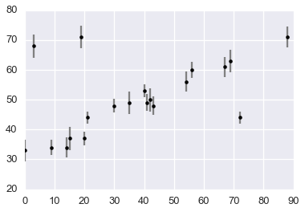

```python
plt.errorbar(x, y, e, fmt='.k', ecolor='gray');
```

Our task is to find a line of best-fit to the data. It's clear upon visual inspection that there are some outliers among these points, but let's start with a simple non-robust maximum likelihood approach.

### Standard Likelihood Approach

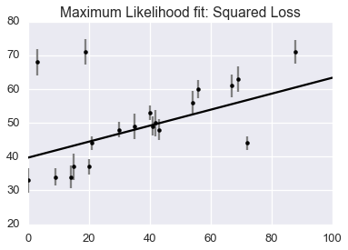

```python
from scipy import optimize

def squared_loss(theta, x=x, y=y, e=e):
    dy = y - theta[0] - theta[1] * x
    return np.sum(0.5 * (dy / e) ** 2)

theta1 = optimize.fmin(squared_loss, [0, 0], disp=False)

xfit = np.linspace(0, 100)
plt.errorbar(x, y, e, fmt='.k', ecolor='gray')
plt.plot(xfit, theta1[0] + theta1[1] * xfit, '-k')
plt.title('Maximum Likelihood fit: Squared Loss');
```

### A Bayesian Approach to Outliers: Nuisance Parameters

The Bayesian approach to accounting for outliers generally involves *modifying the model* so that the outliers are accounted for. For this data, it is abundantly clear that a simple straight line is not a good fit to our data. So let's propose a more complicated model that has the flexibility to account for outliers. One option is to choose a mixture between a signal and a background:

$$ \begin{array}{ll} p(\{x_i\}, \{y_i\},\{e_i\}~|~\theta,\{g_i\},\sigma,\sigma_b) = & \frac{g_i}{\sqrt{2\pi e_i^2}}\exp\left[\frac{-\left(\hat{y}(x_i~|~\theta) - y_i\right)^2}{2e_i^2}\right] \\ &+ \frac{1 - g_i}{\sqrt{2\pi \sigma_B^2}}\exp\left[\frac{-\left(\hat{y}(x_i~|~\theta) - y_i\right)^2}{2\sigma_B^2}\right] \end{array} $$

What we've done is expanded our model with some nuisance parameters: $\{g_i\}$ is a series of weights which range from 0 to 1 and encode for each point $i$ the degree to which it fits the model.

Our model is much more complicated now: it has 22 parameters rather than 2, but the majority of these can be considered nuisance parameters, which can be marginalized-out in the end, just as we marginalized (integrated) over $p$ in the Billiard example. Let's construct a function which implements this likelihood. We'll use the [emcee](http://dan.iel.fm/emcee/current/) package to explore the parameter space.

To actually compute this, we'll start by defining functions describing our prior, our likelihood function, and our posterior:

```python
# theta will be an array of length 2 + N, where N is the number of points
# theta[0] is the intercept, theta[1] is the slope,
# and theta[2 + i] is the weight g_i

def log_prior(theta):
    #g_i needs to be between 0 and 1
    if (all(theta[2:] > 0) and all(theta[2:] < 1)):
        return 0
    else:
        return -np.inf  # recall log(0) = -inf

def log_likelihood(theta, x, y, e, sigma_B):
    dy = y - theta[0] - theta[1] * x
    g = np.clip(theta[2:], 0, 1)  # g<0 or g>1 leads to NaNs in logarithm
    logL1 = np.log(g) - 0.5 * np.log(2 * np.pi * e ** 2) - 0.5 * (dy / e) ** 2
    logL2 = np.log(1 - g) - 0.5 * np.log(2 * np.pi * sigma_B ** 2) - 0.5 * (dy / sigma_B) ** 2
    return np.sum(np.logaddexp(logL1, logL2))

def log_posterior(theta, x, y, e, sigma_B):
    return log_prior(theta) + log_likelihood(theta, x, y, e, sigma_B)
```

Now we'll run the MCMC samples to explore the parameter space:

```python
# Note that this step will take a few minutes to run!

ndim = 2 + len(x)  # number of parameters in the model
nwalkers = 50  # number of MCMC walkers
nburn = 10000  # "burn-in" period to let chains stabilize
nsteps = 15000  # number of MCMC steps to take

# set theta near the maximum likelihood, with
np.random.seed(0)
starting_guesses = np.zeros((nwalkers, ndim))
starting_guesses[:, :2] = np.random.normal(theta1, 1, (nwalkers, 2))
starting_guesses[:, 2:] = np.random.normal(0.5, 0.1, (nwalkers, ndim - 2))

import emcee
sampler = emcee.EnsembleSampler(nwalkers, ndim, log_posterior, args=[x, y, e, 50])
sampler.run_mcmc(starting_guesses, nsteps)

sample = sampler.chain  # shape = (nwalkers, nsteps, ndim)
sample = sampler.chain[:, nburn:, :].reshape(-1, ndim)
```

Once we have these samples, we can exploit a very nice property of the Markov chains. Because their distribution models the posterior, we can integrate out (i.e. marginalize) over nuisance parameters simply by ignoring them!

We can look at the (marginalized) distribution of slopes and intercepts by examining the first two columns of the sample:

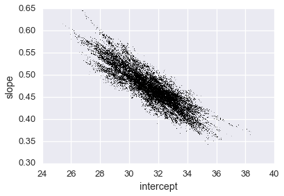

```python
plt.plot(sample[:, 0], sample[:, 1], ',k', alpha=0.1)
plt.xlabel('intercept')
plt.ylabel('slope');
```

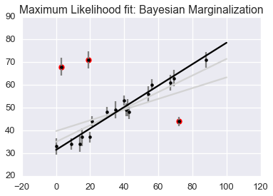

```python
plt.errorbar(x, y, e, fmt='.k', ecolor='gray')
plt.plot(xfit, theta1[0] + theta1[1] * xfit, color='lightgray')
plt.plot(xfit, theta2[0] + theta2[1] * xfit, color='lightgray')
plt.plot(xfit, theta3[0] + theta3[1] * xfit, color='black')
plt.scatter(x[outliers], y[outliers],marker='o',s=40,edgecolors='r',linewidths=2,c='k')
plt.title('Maximum Likelihood fit: Bayesian Marginalization');
```

# Maskininlärning

- Utrusta datorer med kapaciteten att "lära sig" från "data".
  - Data från t.ex. sensorer, internet, ...
  - ... eller från experiment, teoretiska simuleringar
  - Förväntning att datorn skall göra "rimliga" förutsägelser.
- Kategoriseras som
  - Supervised learning (klassifisering, regression)
  - Unsupervised learning (dimensionalitetsreduktion, clustering)
  - Reinforcement learning (inlärning med försenad återkoppling)

[figure not shown]

XKCD web comic: [Machine learning](https://xkcd.com/1838/)

## Maskininlärning del 1:

### Neurala nätverk, deep learning och TensorFlow

[figure not shown]

## Tillämpningar inom allt möjligt

- Textigenkänning
- Bildigenkänning
- Taligenkänning
- Översättning
- Medicinsk diagnos
- Självkörande bilar
- mm, mm,mm

Mycket av detta har blivit möjligt genom tillgång till

- stora datamängder (att träna på)
- nya algoritmer (t.ex. deep learning)
- samt ny teknologi (t.ex. gpu) som möjliggör att utföra maskininlärningen i praktiken.

## Exempel: Bildigenkänning med områdesbeskrivningar

[figure not shown]

från [arXiv:1412.2306](https://arxiv.org/abs/1412.2306)

## Exempel: Addition av två tal som strängar

För den vill vill testa att bygga ett neuralt nätverk rekommenderas [TensorFlow](https://www.tensorflow.org/) som är ett öppet programbibliotek för maskinintelligens genom neurala nätverk. Personligen tyckte jag att TensorFlow blir enklare att använda genom ett python API som heter [Keras](https://keras.io/).

Ett exempel från deras [exempelbibliotek](https://github.com/keras-team/keras/tree/master/examples) finns i en separat ipython notebook som ni gärna får testa.

Uppgiften är att lära ett neuralt nätverk med tre lager och 200.000 parametrar att addera två tresiffriga tal. Både själva additionen och svaret skall representeras som strängar.

```python
# Extracted output from Keras_Addition_rnn.ipynb

# model.system()
```

```
_________________________________________________________________
Layer (type)                 Output Shape              Param #
=================================================================
lstm_1 (LSTM)                (None, 128)               72192
_________________________________________________________________
repeat_vector_1 (RepeatVecto (None, 4, 128)            0
_________________________________________________________________
lstm_2 (LSTM)                (None, 4, 128)            131584
_________________________________________________________________
time_distributed_1 (TimeDist (None, 4, 12)             1548
_________________________________________________________________
activation_1 (Activation)    (None, 4, 12)             0
=================================================================
Total params: 205,324
Trainable params: 205,324
Non-trainable params: 0
_________________________________________________________________
```

```
--------------------------------------------------
Iteration 1
Train on 45000 samples, validate on 5000 samples
Epoch 1/1
45000/45000 [==============================] - 26s 572us/step - loss: 1.8809 - acc: 0.3228 - val_loss: 1.7916 - val_acc: 0.3457
Q 3+368   T 371  ☒ 13
Q 94+32   T 126  ☒ 101
Q 8+466   T 474  ☒ 102
Q 989+717 T 1706 ☒ 1100
Q 4+125   T 129  ☒ 23
Q 996+41  T 1037 ☒ 100
Q 10+245  T 255  ☒ 132
Q 1+759   T 760  ☒ 122
Q 714+489 T 1203 ☒ 1107
Q 517+649 T 1166 ☒ 1167

--------------------------------------------------
```

[...]

```
--------------------------------------------------
Iteration 15
Train on 45000 samples, validate on 5000 samples
Epoch 1/1
45000/45000 [==============================] - 26s 572us/step - loss: 0.5331 - acc: 0.8062 - val_loss: 0.4613 - val_acc: 0.8338
Q 491+493 T 984  ☒ 975
Q 459+48  T 507  ☒ 506
Q 910+974 T 1884 ☑ 1884
Q 582+346 T 928  ☒ 927
Q 313+31  T 344  ☒ 334
Q 717+7   T 724  ☑ 724
Q 87+509  T 596  ☑ 596
Q 545+7   T 552  ☑ 552
Q 313+9   T 322  ☑ 322
Q 602+784 T 1386 ☒ 1387

--------------------------------------------------
```

[...]

```
--------------------------------------------------
Iteration 200
Train on 45000 samples, validate on 5000 samples
Epoch 1/1
45000/45000 [==============================] - 16s 348us/step - loss: 0.0012 - acc: 1.0000 - val_loss: 0.0027 - val_acc: 0.9996
Q 111+289 T 400  ☑ 400
Q 4+663   T 667  ☑ 667
Q 331+54  T 385  ☑ 385
Q 10+201  T 211  ☑ 211
Q 777+324 T 1101 ☑ 1101
Q 9+693   T 702  ☑ 702
Q 470+75  T 545  ☑ 545
Q 999+571 T 1570 ☑ 1570
Q 72+883  T 955  ☑ 955
Q 13+983  T 996  ☑ 996

--------------------------------------------------
```

Fysiker är ofta väldigt snabba på att ta till sig nya möjligheter, och att utveckla dem vidare. Ofta erbjuder forskning inom fundamental fysik väldigt stora utmaningar.

[figure not shown]

### Neutron Reconstruction using Neural Networks

#### Master’s thesis in Subatomic Physics Marcus Polleryd, 2017 pdf

[figure not shown]

## Maskininlärning del 2:

### Gaussprocesser

Antag att det finns en okänd funktion $$ f: x \mapsto y $$

Betrakta sedan följande två frågeställningar: Givet $N$ datapunkter: input=$(x_0, x_1, \ldots, x_N)$, output=$(y_0, y_1, \ldots, y_N)$, vad blir din förutsägelse för:

- $y=f(x)$, dvs hur tror vi att den obekanta funktionen ser ut?
- min($(f(x)$) i något intervall, dvs vad är funktionens minimum (och var inträffar det?)

Bägge dessa frågeställningar dyker ofta upp i väldigt olika sammanhang och tillämpningar.

- En (flerdimensionell) *Gaussdistribution* beskrivs av en vektor med medelvärden $m$ samt en kovariansmatris $K$ $$ \vec{f} = (f_1, \ldots, f_n) \sim \mathcal{N}(m,K) $$
- En *Gaussprocess* kan ses som en generalisering av ovanstående till oändligt många variabler. Gaussprocessen beskrivs av en funktion med medelvärden $m(x)$ samt en kovariansfunktion $K(x,x')$ $$ f(x) \sim \mathcal{GP}(m(x),K(x,x')), $$

```python
#------------------------------------------------------------
# define a squared exponential covariance function
# also known as the RBF kernel
def squared_exponential(x1, x2, h):
    return np.exp(-0.5 * (x1 - x2) ** 2 / h ** 2)

#------------------------------------------------------------
# draw samples from the unconstrained covariance
np.random.seed(1)
xtest = np.linspace(-3, 3, 100)
h = 1.0

mu = np.zeros(len(xtest))
C = squared_exponential(xtest, xtest[:, None], h)
draws = np.random.multivariate_normal(mu, C, 3)
```

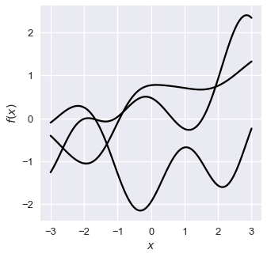

```python
#------------------------------------------------------------
# Plot the diagrams
fig = plt.figure(figsize=(5, 5))


# first: plot a selection of unconstrained functions
ax = fig.add_subplot(111)
ax.plot(xtest, draws.T, '-k')
ax.set_ylabel('$f(x)$');
ax.set_xlabel('$x$');
```

## Exempel #1: 1-dim regression

Vi kommer att demonstrera grundläggande principer för Gaussprocesser samt visa ett exempel på konstruktion av en endimensionell modell för regression.

Det blir kortfattat. Ett bra litteraturtips för mer detaljer är boken [Gaussian Processes for Machine Learning](http://gaussianprocess.org/gpml/chapters/) av Carl Edward Rasmussen och Christopher K. I. Williams.

- $x$ representerar 'input' och $y$ representerar 'output'.
- Eller $y = f(x)$ där funktionen $f(x)$ representerar en process som är okänd för oss.
  - Det kan vara experimentell data som en funktion av en experimentellt modifierbar variabel;
  - eller resultat från en teoretisk simulering som en funktion av en modellparameter. Vi kommer att låta observationerna $y$ inkludera slumpmässigt brus ('noise').

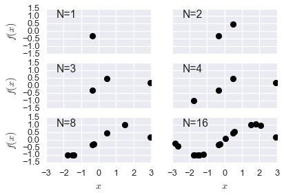

```python
#------------------------------------------------------------
# Plot the data sequentially as it is drawn. When can you guess the generating "function"
fig, axarr = plt.subplots(3,2, sharex=True,sharey=True)

for i,ni in enumerate([1,2,3,4,8,16]):
    # Note the use of floor division '//' and modulo '%' to get the row and column
    ax = axarr[i//2,i%2]
    ax.plot(x[:ni], y[:ni], 'ok')
    ax.text(0.1,0.8,'N=%i' %ni,transform=ax.transAxes)
    if i%2==0: ax.set_ylabel('$f(x)$')
    if i//2==2: ax.set_xlabel('$x$')
```

### Gaussprocesser

Först importerar vi modulen GPy. Det finns andra alternativ, t.e.x scikit-learn.

```python
import GPy
```

För att konstruera en GP modell behöver vi data och en kernel.

```python
kernel = GPy.kern.RBF(input_dim=1, variance=1., lengthscale=1.)
```

```python
m = GPy.models.GPRegression(x,y,kernel)
```

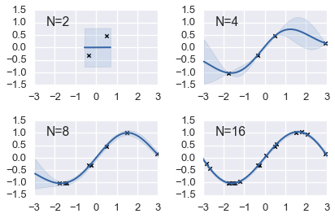

```python
fig = GPy.plotting.plotting_library().figure(2, 2)

for i,ni in enumerate([2,4,8,16]):
    # Create model from data and kernel
    kernel = GPy.kern.RBF(input_dim=1, variance=1., lengthscale=1.)
    m = GPy.models.GPRegression(x[:ni], y[:ni],kernel)
    # Optimize the model parameters to maximize the data likelihood
    m.optimize(messages=True)
    # Plot. Shaded bands indicate 95% confidence interval.
    m.plot(figure=fig, row=(i//2+1), col=(i%2+1),legend=False)
    ax =plt.gca()
    ax.set_xlim([-3,3]); ax.set_ylim([-1.5,1.5])
    ax.text(0.1,0.8,'N=%i' %ni,transform=ax.transAxes)
```

Minns ni de stora parameterrummen i chiral EFT,

... och den stora beräkningskostnaden för att göra en prediktion?

Tänk er då att försöka göra en osäkerhetsanalys på en sådan teori.

### Chiral effective field theory with machine learning

#### Bachelor’s thesis in Subatomic Physics Johannes Aspman, Emil Ejbyfeldt, Anton Kollmats, Maximilian Leyman, 2016 pdf

[figure not shown]

11 parametrar, 100 träningspunkter, 100.000 emuleringar

# Slutsats

Här framträder en bild av en modern ingenjör. Vi har gjort:

- lite fysik, lite statistik, lite beräkningsfysik och lite maskininlärning;
- tillsammans ger detta verktyg att ta oss an en väldigt bred palett av utmaningar;
- och att försöka förstå vad våra resultat innebär.

Vem kan klara något sådant?

Svar: en fysiker

## Data science

[The Data Science Venn Diagram](http://drewconway.com/zia/2013/3/26/the-data-science-venn-diagram) by Drew Conway.

[figure not shown]

## The Pi-shaped scientist

Introduced by Alex Szalay.

[figure not shown]

I detta sammanhang kan jag avslutningsvis nämna att det pågår ett intensivt arbete att skapa ett nytt mastersprogram i fysik (kommer att sjösättas hösten 2019)

- som utnyttjar kunskapsbredden och problemlösarförmågan som finns hos dagens fysikstudenter (och teknisk matematik)
- samt expertisen som finns hos lärarna,
- där det fortfarande erbjuds möjlighet till fördjupning,
- men där kursutbudet anpassas för att lära ut en uppdaterad uppsättning med verktyg och förmågor.

Dvs en **Pi-formad** ingenjör!